# COMP47670 Assignment 1: Data Collection & Preparation

Name : Safiya Rehmat

Student Id : 18200494

## Introduction

In this project, I analyze cities in Europe based on Quallity of Life Index using various factors like Cost of Living, Environment Quality, HEalthcare, Housing, Business Freedom, Education, Commute etc.

Data Collected from APIs is stored in a sub-directory Data

Results obtained from the analysis are stored in a sub-directory Results

```python
# Import the relevant libraries
import requests
import pandas as pd
import json
import numpy as np

import os
os.environ['PROJ_LIB']= r'C:\Users\Safiya\Anaconda3\pkgs\proj4-5.2.0-ha925a31_1\Library\share'

import matplotlib
import matplotlib.pyplot as plt
%matplotlib inline

from pandas.plotting import scatter_matrix
from mpl_toolkits.basemap import Basemap
```

## Task 1 : Select an API as your data source

The API I have chosen for the project is [developers.teleport.org.](https://developers.teleport.org/api/getting_started/)

It provides data about the quality of life in different cities across the world. It is an open API and does not need any authentication key.

The data consists of scores provided on various features like Cost of Living (which is further aggregated by add costs of everyday items and normalizing them), Healthcare, Travel, Safety, Tolerance etc . Info about each feature is also available on the API.

In this project, I am analyzing these scores for cities in Europe to find the best cities according to specific criteria

```python
# Construct the query
base_endpoint = "https://api.teleport.org/api/"
method = "/continents/geonames:EU/urban_areas/"

# Configuration
params = {
            "format" : "json", # we require the response in json format
         }
```

## Task 2 : Collect the data from api of your choice

The diagram below explains the process of collecting data from the chosen API:

[figure not shown]

There are 3 methods defined below :

```
    1. get_response(url) : It hits the API, collects the data in json format and returns it.
    2. write_json(filename, content) : Writes json data to the File system.
    3. read_json(filename) : Reads a json file and returns the data
```

These methods are used to collect the data so that it can be used further.

```python
def get_response(url):
    response = requests.get(url,params=params)
    # print(f"status code: {response.status_code}")
    # print(f"url:{response.url}")
    return response.json()

def write_json(filename, content):
    with open(filename, 'w') as outfile:
        json.dump(content, outfile)

def read_json(filename):
    with open(filename) as json_file:
        data = json.load(json_file)
    return data
```

```python
# request the url and store the response in a variable
response = get_response(base_endpoint+method)
# storing the api response as backup. IF the api is down at some point, this data can be used to run the application
write_json("Data/Urban Areas data.txt", response)
```

```python
urbanareas = response["_links"]["ua:items"]
pd.set_option('display.max_colwidth', -1)
df = pd.DataFrame(urbanareas)
df.to_csv("Data/Urban Areas Links.csv")
```

## Task 3 : Parse and store the data in appropriate format

The code below collects :

1. The scores for all categories for all cities in Europe that were retireved from the API in Task 2.
2. The bounding box details for all cities in Europe. This is need for map visualiztion during analysis.

```python
## Collect scores for each city as a dictionary and add it to datalist.

#datalist contains all scores for all cities
datalist = []
for area in urbanareas:
    #initialize a new dictionary for each city and add the each category scores to it
    datadict = {}
    datadict["areaname"] = area['name']
    area_link = area['href']+'scores/' #can be navigated from get_response(area[href])["_links"]["ua_scores"][href]
    #get all categories of scores by calling the API using get_response method
    score_categories = get_response(area_link)["categories"]
    #iterate over each category to get the score values
    for category in score_categories:
        datadict[category["name"]] = category["score_out_of_10"]
    #append the dictionary containing all scores to the datalist
    datalist.append(datadict)
```

```python
## Collect the bounding-box locations for each city as a dictionary and add it to datalist.

#datalist contains all location for all cities
locationlist=[]
for area in urbanareas:
    dic = {}
    #get the location for each city by calling the API and extracting the lat-lon values from the response
    response= get_response(area["href"])["bounding_box"]["latlon"]
    #populate the dictionary with the bounding-box values
    dic["areaname"] = area["name"]
    dic["north"] = response["north"]
    dic["east"] = response["east"]
    dic["west"] = response["west"]
    dic["south"] = response["south"]
    #append the dictionar containing location values to locationlist
    locationlist.append(dic)
#print(locationlist)
```

The scores are stored as a csv file for any further processing. The 2 files created are :

1. Europe data.csv : Contains scores for all cities for all features
2. Location data. csv : Contains location bounding box for all cities

```python
# create a dataframe for the scores data
df = pd.DataFrame(datalist)
display(df.shape)
display(df.head())
# export the dataframe
df.to_csv("Data/Europe_data.csv", encoding="utf-8")
```

```
(111, 18)
```

|  | Business Freedom | Commute | Cost of Living | Economy | Education | Environmental Quality | Healthcare | Housing | Internet Access | Leisure & Culture | Outdoors | Safety | Startups | Taxation | Tolerance | Travel Connectivity | Venture Capital | areaname |
| --- | --- | --- | --- | --- | --- | --- | --- | --- | --- | --- | --- | --- | --- | --- | --- | --- | --- | --- |
| 0 | 9.940000 | 6.31175 | 4.015 | 4.8865 | 5.3665 | 7.63300 | 9.130667 | 6.1315 | 8.373 | 3.1870 | 4.1300 | 9.6165 | 2.8270 | 5.0680 | 9.7385 | 3.5360 | 2.512 | Aarhus |
| 1 | 8.836667 | 6.11850 | 3.824 | 5.0530 | 6.1800 | 7.59725 | 8.899000 | 3.0530 | 4.523 | 8.8740 | 5.3070 | 8.5035 | 7.9715 | 4.9550 | 8.3680 | 8.3245 | 6.107 | Amsterdam |
| 2 | 0.000000 | 0.00000 | 0.000 | 0.0000 | 0.0000 | 7.25600 | 0.000000 | 3.9690 | 7.186 | 2.1320 | 3.5885 | 9.5535 | 1.0000 | 4.4750 | 8.7035 | 0.5000 | 0.000 | Andorra |
| 3 | 6.169000 | 5.21975 | 6.500 | 3.3200 | 3.1625 | 3.80225 | 7.258333 | 9.0525 | 2.228 | 7.8760 | 6.4830 | 6.7585 | 4.4040 | 4.1665 | 6.2680 | 3.7070 | 2.325 | Athens |
| 4 | 7.119667 | 5.69925 | 6.074 | 4.2960 | 5.0290 | 3.66550 | 8.366667 | 6.3230 | 6.468 | 8.5915 | 5.8280 | 7.4075 | 7.7585 | 3.8940 | 7.4715 | 5.8060 | 5.655 | Barcelona |

```python
# create a dataframe for the LOCATIONS data
df = pd.DataFrame(locationlist)
display(df.shape)
display(df.head())
# export the dataframe
df.to_csv("Data/Location_data.csv", encoding="utf-8")
```

```
(111, 5)
```

|  | areaname | east | north | south | west |
| --- | --- | --- | --- | --- | --- |
| 0 | Aarhus | 10.255086 | 56.237636 | 56.118572 | 10.108511 |
| 1 | Amsterdam | 5.347000 | 52.629000 | 52.163000 | 4.465000 |
| 2 | Andorra | 1.786639 | 42.655791 | 42.428749 | 1.408705 |
| 3 | Athens | 24.421000 | 38.365000 | 37.514000 | 22.949000 |
| 4 | Barcelona | 2.312000 | 41.533000 | 41.246000 | 1.898000 |

## Task 4 : Load the data and perform pre-processing

We are going to pre-process the data in 2 parts :

```
1. Part 1 involves processing the scores
2. Part 2 involves processing the locations
```

## PART 1 : Scores Data Pre-Processing

### Steps involved:

1. Dropping categories with many missing values
2. Interpolating missing data for all category scores
3. Feature engineering : Combining features to extract insights
4. Normalizing the scores by the mean-score for that category

```python
# Load the scores we stored in Task 3
df = pd.read_csv("Data/Europe_data.csv")
```

#### Drop Categories with missing Values

```python
#Find missing values.
# This API does not give nulls for missing data, it returns 0 instead. Thus we first need to replace all zeros
df = df.replace(0,np.NaN)
# Now  we can analyze the missing values for each score category
print("Number of missing values: \n"+str( df.isnull().sum() ))
```

```
Number of missing values:
Unnamed: 0               1
Business Freedom         2
Commute                  4
Cost of Living           4
Economy                  2
Education                4
Environmental Quality    0
Healthcare               1
Housing                  0
Internet Access          0
Leisure & Culture        0
Outdoors                 0
Safety                   0
Startups                 1
Taxation                 0
Tolerance                0
Travel Connectivity      0
Venture Capital          28
areaname                 0
dtype: int64
```

```python
# next we drop categories which have a lot of missing data as interpolating data in this case can be mis-leading
df.drop("Venture Capital", axis=1, inplace=True)
df.drop("Unnamed: 0", axis=1, inplace=True)
```

#### Interpolate Missing Data

```python
#for all remaining categories, we interpolate missing values
for fields in df :
    if(fields!="areaname"):
        df[fields] = df[fields].fillna(df[fields].mean())
```

```python
# view the data after analyzing
df.describe()
## We can see the minimum values are greater than 0, thus confirming that missing data is interpolated successfully.
```

|  | Business Freedom | Commute | Cost of Living | Economy | Education | Environmental Quality | Healthcare | Housing | Internet Access | Leisure & Culture | Outdoors | Safety | Startups | Taxation | Tolerance | Travel Connectivity |
| --- | --- | --- | --- | --- | --- | --- | --- | --- | --- | --- | --- | --- | --- | --- | --- | --- |
| count | 111.000000 | 111.000000 | 111.000000 | 111.000000 | 111.000000 | 111.000000 | 111.000000 | 111.000000 | 111.000000 | 111.000000 | 111.000000 | 111.000000 | 111.000000 | 111.000000 | 111.000000 | 111.000000 |
| mean | 7.811908 | 5.588002 | 5.782393 | 4.679624 | 4.547355 | 6.669304 | 7.780206 | 6.669059 | 5.849189 | 5.729860 | 4.367009 | 7.984090 | 4.026582 | 4.834153 | 7.381486 | 4.682036 |
| std | 1.495407 | 0.537110 | 1.968166 | 1.204335 | 1.410487 | 1.839427 | 1.658475 | 2.104183 | 1.558061 | 1.911121 | 1.388290 | 0.932287 | 1.634888 | 1.613578 | 1.309619 | 2.139529 |
| min | 2.580333 | 2.293750 | 1.000000 | 1.275500 | 0.500000 | 1.656250 | 0.706333 | 1.000000 | 2.228000 | 1.115000 | 0.500000 | 5.252000 | 1.000000 | 1.883000 | 3.475000 | 0.500000 |
| 25% | 6.460333 | 5.359125 | 4.766500 | 4.112750 | 4.159250 | 5.229125 | 7.236167 | 5.723750 | 4.865000 | 4.491500 | 3.726750 | 7.278250 | 3.023750 | 3.894000 | 6.725750 | 3.020000 |
| 50% | 8.088333 | 5.627750 | 5.612000 | 4.691000 | 4.549000 | 7.048250 | 8.432667 | 6.928500 | 5.761500 | 5.443000 | 4.671000 | 8.032500 | 3.734500 | 4.937000 | 7.483000 | 4.750500 |
| 75% | 8.992000 | 5.918375 | 7.099000 | 5.438000 | 5.207000 | 8.184875 | 8.842333 | 8.214500 | 6.554000 | 7.062000 | 5.343500 | 8.666750 | 4.800750 | 5.954500 | 8.333000 | 6.109750 |
| max | 9.940000 | 6.728500 | 10.000000 | 7.514500 | 9.027000 | 9.416000 | 9.739333 | 9.778000 | 9.716000 | 9.816500 | 7.331000 | 9.616500 | 10.000000 | 9.475000 | 9.738500 | 10.000000 |

#### Feature engineering : Combining features to extract insights

There are 2 methoods defined here:

```
1. get_subset() : This method returns the data for all fields specified in the parameter
2. calulate_average_rating() : Aggregate the scores for all fields in the data to provide a scoring index
```

```python
def get_subset(df,fields):
    df_group = df[fields]
    df_group.is_copy = False
    return df_group

def calculate_average_rating(df):
    df["Average Score"] = df.mean(axis=1)
    df = df[['areaname','Average Score']]
```

We have grouped score categories into 4 groups:

```
1. Group 1: Business and Economy
2. Group 2: Life Quality
3. Group 3: Leisure Opporutnities
4. Group 4: Cost of Living
```

Task 5 elaborates on the process to combine similar categories into groups. We basically find correlations between scores of different categories and then combine similar ones to gain better insights.

```python
group1_fields = [ 'areaname', 'Business Freedom', 'Startups','Taxation', 'Economy','Education']
group2_fields = [ 'areaname', 'Housing', 'Internet Access', 'Safety', 'Cost of Living', 'Travel Connectivity','Healthcare','Environmental Quality']
group3_fields = [ 'areaname', 'Outdoors', 'Commute', 'Leisure & Culture','Tolerance']
group4_fields = [ 'areaname', 'Cost of Living', 'Taxation']
```

#### Normalizing by Mean Score

The method scale_rating(df) is used to normalize all the scores by the mean score for the cateogry.

```python
def scale_rating(df):
    mean_score = df['Average Score'].mean()
    df['Average Score'] = df.apply(lambda row: row['Average Score']-mean_score, axis=1)
```

#### Combining all The steps for pre-Processinf scores:

```python
#This method combines all the methods defined in the steps mentioned above and returns processed data
def get_filtered_data(df,fields):
    df_group = get_subset(df,fields)
    calculate_average_rating(df_group)
    scale_rating(df_group)
    df_group.describe()
    return df_group

#getting data for each group
df_group1 = get_filtered_data(df,group1_fields)
df_group2 = get_filtered_data(df,group2_fields)
df_group3 = get_filtered_data(df,group3_fields)
df_group4 = get_filtered_data(df,group4_fields)

#getting the mean overall score for all categories
df["Average Score"] = df.mean(axis=1)
df_averagescore = df[["areaname", "Average Score"]]
```

## PART 2 : Location Data Pre-Processing

### Pre-processing location data involves:

1. Loading the location data
2. Calculating the lattitude and longitude values from the bounding-box data
3. Dropping the remaining location values

```python
#Load the location data
loc_df = pd.read_csv("Data/Location_data.csv")

#drop the unnamed column : This corresponds to serial no. and is not useful for analysis
loc_df.drop("Unnamed: 0", axis=1, inplace=True)

#Calculate the lat/long values from the bounding-box data we got from the API calls
loc_df["lat"] = (loc_df["north"]+loc_df["south"])/2
loc_df["lon"] = (loc_df["east"]+loc_df["west"])/2

loc_df.set_index("areaname", inplace=True)
# Filter the values and remove all columns except the latitude and longitides
loc_df=loc_df[['lat','lon']]
```

```python
loc_df.describe()
```

|  | lat | lon |
| --- | --- | --- |
| count | 111.000000 | 111.000000 |
| mean | 49.263679 | 9.198646 |
| std | 6.746539 | 14.160489 |
| min | 28.119594 | -71.341650 |
| 25% | 44.830119 | 0.006893 |
| 50% | 50.046765 | 9.165000 |
| 75% | 53.378529 | 18.180273 |
| max | 65.178000 | 44.882950 |

## Task 5 : Analysis

## Feature Engineering : Correlations between features

Before we can analyze the data, we need to analyze the different categories of score values so that we can group them to get interesting insights. We use correlation between features to do this step

We have a number of features on which each city is scored, like Business freedom, Cost of living, taxation etc.

We analyze the different features and find the related ones below, based on their degree of correlation. Similar features are then grouped together to form the different groups on which is city can then be assesed/ analyzed

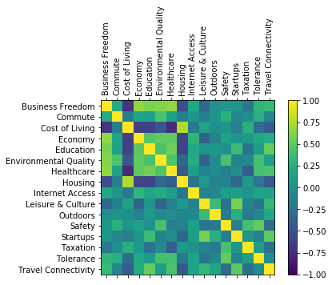

```python
def get_features_correlation(names,title):
    correlations = df[names].corr()
    # plot correlation matrix
    fig = plt.figure()
    ax = fig.add_subplot(111)
    cax = ax.matshow(correlations, vmin=-1, vmax=1)
    fig.colorbar(cax)
    ticks = np.arange(0,16,1)
    ax.set_xticks(ticks)
    plt.xticks(rotation=90)
    ax.set_yticks(ticks)
    ax.set_xticklabels(names)
    ax.set_yticklabels(names)
    plt.savefig(title)
    plt.show()

names = ['Business Freedom','Commute','Cost of Living','Economy','Education', 'Environmental Quality','Healthcare','Housing','Internet Access',
         'Leisure & Culture', 'Outdoors','Safety','Startups','Taxation','Tolerance','Travel Connectivity']
get_features_correlation(names,"Results/Correlation between features.jpg")
```

The graph above shows the correlation matrix between all pairs of features.

```
1. group1 = 'Business Freedom', 'Startups','Taxation', 'Economy','Education'
2. group2s ='Housing', 'Internet Access', 'Safety', 'Cost of Living', 'Travel connectivity','Healthcare','Environmental Quality'
3. group3 = 'Outdoors', 'Commute', 'Leisure & Culture','Tolerance'
4. group4 = 'Cost of Living', 'Taxation'
```

## Visualization of Results

We plot 2 kinds of graphs for each analysis :

[output not shown]

```python
#displays the bar-plot for scores of top 10 cities
def plot_bargraph(df):
    df.plot(kind='barh',x="areaname", y="Average Score")

#gets the location (lat/long values) for the top 10 cities, used in map plots
def get_top10_loc(df):
    result = pd.merge(df,loc_df,on='areaname')
    return result

#displays and stores the map plot for top 10 cities
def get_map(lat,lon,labels,title):
    fig, ax = plt.subplots(figsize=(10,20))
    m = Basemap(resolution='l', # c, l, i, h, f or None
                projection='merc',
                lat_0=44.5, lon_0=-4.36,
                llcrnrlon=-11, llcrnrlat= 35.8, urcrnrlon=34.7, urcrnrlat=59.67)
    m.drawmapboundary(fill_color='#46bcec')
    m.fillcontinents(color='#f2f2f2',lake_color='#46bcec')
    m.drawcoastlines()
    m.drawcountries()
    x,y = m(lon,lat)
    m.scatter(x, y, marker = 'D', color='r',zorder=5)
    for label, xpt, ypt in zip(labels, x, y):
        plt.text(xpt+10000, ypt+5000, label)
    plt.savefig(title)
    return m
```

## Factors for Quality of Life Analysis :

In this section, we will look at each of them in detail.

### Top 10 cities for Business and Economy in Europe

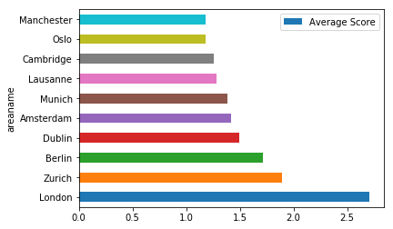

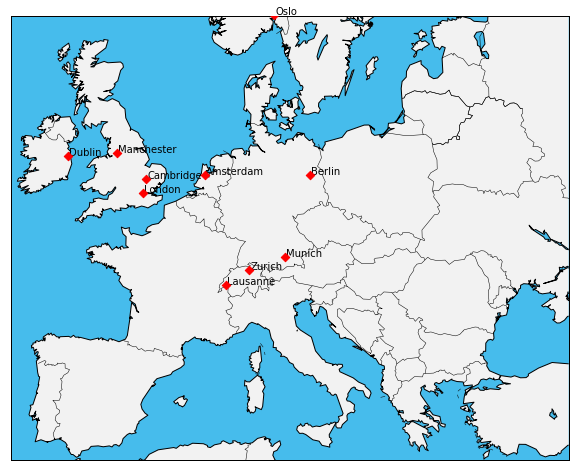

```python
top10_group1 = df_group1.nlargest(10,['Average Score'])
#print(top10_group1)
plot_bargraph(top10_group1)

result = get_top10_loc(top10_group1)
lat = result["lat"].values.tolist()
lon= result["lon"].values.tolist()
labels = result["areaname"].values.tolist()

m = get_map(lat,lon,labels,"Results/Top 10 cities for Business in Europe.jpg")
```

### Top 10 cities for Life Quality in Europe

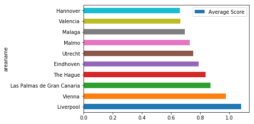

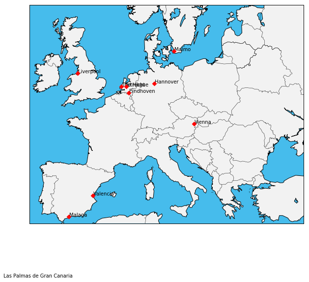

```python
top10_group2 = df_group2.nlargest(10,['Average Score'])
#print(top10_group2)
plot_bargraph(top10_group2)

result = get_top10_loc(top10_group2)
lat = result["lat"].values.tolist()
lon= result["lon"].values.tolist()
labels = result["areaname"].values.tolist()

m = get_map(lat,lon,labels,"Results/Top 10 cities for Life Quality in Europe.jpg")
```

### Top 10 cities for Leisure Opportunities in Europe

```
       areaname  Outdoors  Commute  Leisure & Culture  Tolerance  \
69   Munich      7.3310    6.01400  7.3360             8.4745
105  Vienna      5.2945    6.21325  8.5215             8.9640
1    Amsterdam   5.3070    6.11850  8.8740             8.3680
61   Madrid      6.2200    5.28575  9.3380             7.6650
54   Lisbon      5.6910    5.31575  7.8335             9.5970
8    Berlin      5.4750    6.19600  8.8810             7.1775
4    Barcelona   5.8280    5.69925  8.5915             7.4715
79   Prague      4.9010    5.84650  8.4645             8.1985
103  Valencia    6.3315    5.80900  7.0780             7.9350
26   Copenhagen  4.6710    6.29550  7.0630             9.0955

     Average Score
69   1.522285
105  1.481723
1    1.400285
61   1.360598
54   1.342723
8    1.165785
4    1.130973
79   1.086035
103  1.021785
26   1.014660
```

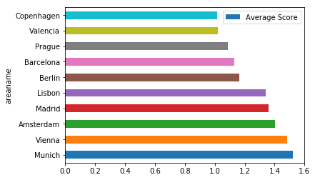

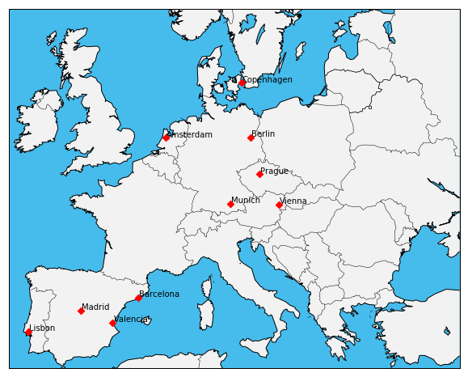

```python
top10_group3 = df_group3.nlargest(10,['Average Score'])
print(top10_group3)
plot_bargraph(top10_group3)

result = get_top10_loc(top10_group3)
lat = result["lat"].values.tolist()
lon= result["lon"].values.tolist()
labels = result["areaname"].values.tolist()

m = get_map(lat,lon,labels,"Results/Top 10 cities for Leisure Opportunities in Europe.jpg")
```

```
       areaname  Cost of Living  Taxation  Average Score
88  Skopje       9.110           9.4750    3.984227
95  Tbilisi      9.765           8.0550    3.601727
86  Sarajevo     8.659           9.1180    3.580227
89  Sofia        8.550           8.7205    3.326977
24  Cluj-Napoca  8.794           6.8390    2.508227
23  Chisinau     9.343           6.2325    2.479477
59  Lviv         10.000          5.4780    2.430727
19  Bucharest    8.516           6.8390    2.369227
47  Kiev         9.817           5.4780    2.339227
67  Minsk        9.289           5.9260    2.299227
```

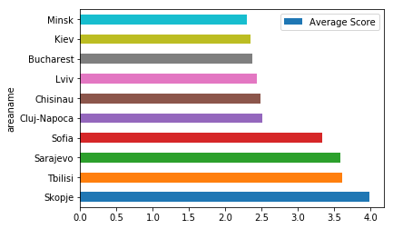

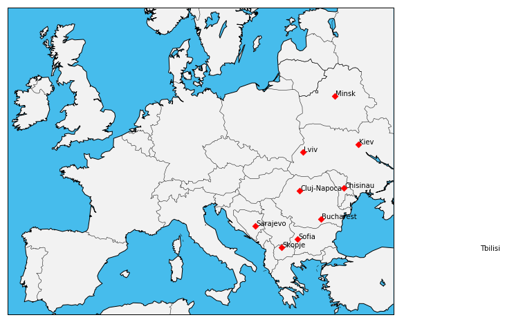

```python
top10_group4 = df_group4.nlargest(10,['Average Score'])
print(top10_group4)
plot_bargraph(top10_group4)

result = get_top10_loc(top10_group4)
lat = result["lat"].values.tolist()
lon= result["lon"].values.tolist()
labels = result["areaname"].values.tolist()

m = get_map(lat,lon,labels,"Results/Top 10 Most Expensive cities in Europe.jpg")
```

## Overall Top 10 cities in Europe

```
       areaname  Average Score
69   Munich      6.944422
8    Berlin      6.773198
57   London      6.708703
105  Vienna      6.676047
1    Amsterdam   6.649245
26   Copenhagen  6.606797
110  Zurich      6.579552
55   Liverpool   6.540474
102  Utrecht     6.479016
79   Prague      6.451818
```

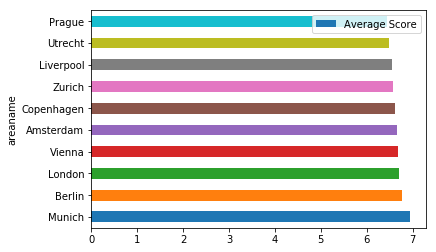

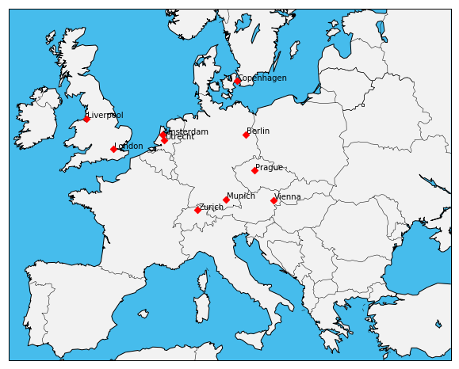

```python
top10_averagescore = df_averagescore.nlargest(10,['Average Score'])
print(top10_averagescore)
plot_bargraph(top10_averagescore)

result = get_top10_loc(top10_averagescore)
lat = result["lat"].values.tolist()
lon= result["lon"].values.tolist()
labels = result["areaname"].values.tolist()

m = get_map(lat,lon,labels,"Results/ Overall Top 10 cities in Europe.jpg")
```